# Final 102

#### Explaining the task and process of a data scientist using examples from this portfolio

```python
import pandas as pd
import seaborn as sns
hostels = pd.read_csv('../data/hostel.csv')
penguins = sns.load_dataset("penguins")
```

Below we have the same example from 101. A datascientist would start of writing a line of code to get the data to be represented in a meaningful way. In this example we have a correlation table that uses colors to show how well two different types of variables are correlated to each other. After we have our meaningful represented data we can analyse it. When analyizing the table we can find out useful information about or table in this case we can see for example that the facility and the summary.score have a close correlation to on another. This can be a result we found.

```python
hostels.corr().style.background_gradient(cmap='coolwarm', axis=None).set_precision(2)
```

|  | Unnamed: 0 | price.from | summary.score | atmosphere | cleanliness | facilities | location.y | security | staff | valueformoney | lon | lat |
| --- | --- | --- | --- | --- | --- | --- | --- | --- | --- | --- | --- | --- |
| Unnamed: 0 | 1.00 | 0.10 | -0.03 | -0.01 | -0.00 | -0.01 | -0.05 | -0.02 | 0.01 | -0.08 | 0.05 | 0.09 |
| price.from | 0.10 | 1.00 | -0.05 | -0.13 | 0.00 | 0.06 | -0.01 | -0.03 | -0.04 | -0.14 | 0.02 | 0.01 |
| summary.score | -0.03 | -0.05 | 1.00 | 0.84 | 0.84 | 0.90 | 0.63 | 0.79 | 0.83 | 0.87 | -0.07 | -0.04 |
| atmosphere | -0.01 | -0.13 | 0.84 | 1.00 | 0.64 | 0.70 | 0.48 | 0.54 | 0.68 | 0.73 | -0.09 | -0.05 |
| cleanliness | -0.00 | 0.00 | 0.84 | 0.64 | 1.00 | 0.80 | 0.41 | 0.59 | 0.63 | 0.69 | -0.06 | -0.03 |
| facilities | -0.01 | 0.06 | 0.90 | 0.70 | 0.80 | 1.00 | 0.48 | 0.64 | 0.69 | 0.75 | -0.05 | -0.03 |
| location.y | -0.05 | -0.01 | 0.63 | 0.48 | 0.41 | 0.48 | 1.00 | 0.38 | 0.42 | 0.46 | -0.09 | -0.03 |
| security | -0.02 | -0.03 | 0.79 | 0.54 | 0.59 | 0.64 | 0.38 | 1.00 | 0.69 | 0.68 | 0.02 | -0.00 |
| staff | 0.01 | -0.04 | 0.83 | 0.68 | 0.63 | 0.69 | 0.42 | 0.69 | 1.00 | 0.63 | -0.02 | -0.01 |
| valueformoney | -0.08 | -0.14 | 0.87 | 0.73 | 0.69 | 0.75 | 0.46 | 0.68 | 0.63 | 1.00 | -0.06 | -0.04 |
| lon | 0.05 | 0.02 | -0.07 | -0.09 | -0.06 | -0.05 | -0.09 | 0.02 | -0.02 | -0.06 | 1.00 | 0.79 |
| lat | 0.09 | 0.01 | -0.04 | -0.05 | -0.03 | -0.03 | -0.03 | -0.00 | -0.01 | -0.04 | 0.79 | 1.00 |

Another example. Here we have a hist chart that shows how often hostels within a certain price rage occure. What's interesting about this example is that just using the raw data we get a histogram which won't be very useful. Due to outliers our histogram gets messed up. A data scientist also has to deal with these sort of things and find solutions in such a way the data becomes meaningful and insightful again. In our case we just simply remove the two records which have an absurtly high price. In other cases you may want to do something else to the data or use a different visual that's better suited to represent the data which has outliers.

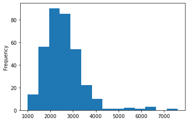

```python
high_price_filter = hostels['price.from'] < 10**5
hostels['price.from'][high_price_filter].plot(kind='hist', bins=14)
```